# R Notebook

## — Repeated Exploratory Data Analysis (EDA) —

```r
# Import packages

library(readr)
library(visdat)
library(dplyr)
library(ggplot2)
library(psych)
library(odbc)
library(DBI)
library(dbscan)
library(naniar)
library(cocor)
library(gridExtra)
library(corrgram)
# 'mechkar' - written by Tomas Carpati
source("C:/Users/Avishai/Documents/General/Personal/DS Course/Google drive content/Projects/Final project-ASHRAE-Great Energy Predictor III/Scripts/R/mechkar.R")
source("C:/Users/Avishai/Documents/General/Personal/DS Course/Google drive content/Projects/Final project-ASHRAE-Great Energy Predictor III/Scripts/R/utils.R")
```

Import of ‘ff_train_agg’ dataset from check point 2:

```r
ff_train_agg <- data.frame(read.csv("C:/Users/Avishai/Documents/General/Personal/DS Course/Google drive content/Projects/Final project-ASHRAE-Great Energy Predictor III/Data/CheckPoint2/ff_train_agg.csv"))
ff_train_agg
```

| site_id | building_id | date | time_range_x_mode | time_range_y_mode | meter_reading_sum | precip_depth_sum | precip_depth_min | precip_depth_max | precip_depth_sd | air_temperature_mean | air_temperature_min | air_temperature_max | air_temperature_sd | dew_temperature_mean | dew_temperature_min | dew_temperature_max | sea_level_pressure_mean | sea_level_pressure_min | sea_level_pressure_max | wind_speed_mean | wind_speed_min | wind_speed_max | wind_speed_sd | rel_humid_mean | rel_humid_min | rel_humid_max | cloud_coverage_mode | cloud_coverage_max | cloud_coverage_sd | … |
| --- | --- | --- | --- | --- | --- | --- | --- | --- | --- | --- | --- | --- | --- | --- | --- | --- | --- | --- | --- | --- | --- | --- | --- | --- | --- | --- | --- | --- | --- | --- |
| 0 | 103 | 2016-02-29 | -0.5 | -0.866 | 3672.32 | 0 | 0 | 0 | 0 | 20.97500 | 13.3 | 25.0 | 4.0095422 | 2 | 2 | 3 | 4 | 4 | 4 | 1.287500 | 0.0 | 3.1 | 1.1752659 | 2 | 2 | 3 | 6 | 6 | 0.3535534 | … |
| 0 | 103 | 2016-02-29 | 1.0 | 0.000 | 1350.74 | 0 | 0 | 0 | 0 | 20.00000 | 16.7 | 24.4 | 3.1377881 | 3 | 2 | 3 | 4 | 4 | 4 | 2.000000 | 0.0 | 3.1 | 1.3416408 | 2 | 2 | 2 | 2 | 5 | 1.8468119 | … |
| 0 | 103 | 2016-03-01 | -0.5 | 0.866 | 1266.30 | 0 | 0 | 0 | 0 | 14.23750 | 13.9 | 15.0 | 0.5012484 | 3 | 3 | 3 | 4 | 4 | 4 | 0.450000 | 0.0 | 2.1 | 0.8485281 | 4 | 4 | 3 | 2 | 4 | 1.2817399 | … |
| 0 | 103 | 2016-03-01 | 1.0 | 0.000 | 1604.00 | 0 | 0 | 0 | 0 | 21.73750 | 17.8 | 26.7 | 3.5576628 | 3 | 3 | 3 | 3 | 3 | 3 | 3.100000 | 2.1 | 5.1 | 0.9258201 | 2 | 2 | 3 | 4 | 6 | 2.0000000 | … |
| 0 | 103 | 2016-03-02 | -0.5 | 0.866 | 1604.00 | 0 | 0 | 0 | 0 | 15.47500 | 14.4 | 17.2 | 0.9662150 | 3 | 3 | 3 | 3 | 3 | 3 | 2.012500 | 1.5 | 2.6 | 0.3603074 | 4 | 4 | 3 | 0 | 6 | 2.2638463 | … |
| 0 | 103 | 2016-03-02 | -0.5 | -0.866 | 6795.89 | 0 | 0 | 0 | 0 | 23.47500 | 17.8 | 27.2 | 3.3728962 | 3 | 3 | 3 | 3 | 3 | 3 | 5.400000 | 3.1 | 7.2 | 1.4842025 | 2 | 2 | 3 | 6 | 6 | 0.3535534 | … |
| 0 | 103 | 2016-03-02 | 1.0 | 0.000 | 1730.63 | 0 | 0 | 0 | 0 | 21.80000 | 16.7 | 27.2 | 3.6816146 | 3 | 2 | 3 | 3 | 3 | 3 | 4.437500 | 2.6 | 7.7 | 2.0056616 | 2 | 2 | 2 | 4 | 5 | 0.5175492 | … |
| 0 | 103 | 2016-03-03 | -0.5 | 0.866 | 1477.37 | 0 | 0 | 0 | 0 | 14.01250 | 12.8 | 15.6 | 0.8838835 | 2 | 2 | 2 | 3 | 3 | 3 | 2.462500 | 1.5 | 3.1 | 0.5423165 | 3 | 3 | 2 | 7 | 8 | 1.0350983 | … |
| 0 | 103 | 2016-03-03 | -0.5 | -0.866 | 5529.59 | 0 | 0 | 0 | 0 | 22.78750 | 16.1 | 26.1 | 3.6988174 | 2 | 2 | 3 | 3 | 3 | 3 | 2.887500 | 0.0 | 4.6 | 1.6391962 | 2 | 1 | 2 | 7 | 8 | 0.7071068 | … |
| 0 | 103 | 2016-03-03 | 1.0 | 0.000 | 1646.21 | 0 | 0 | 0 | 0 | 22.42500 | 17.8 | 26.1 | 3.2547767 | 2 | 2 | 3 | 2 | 3 | 2 | 3.287500 | 2.1 | 4.6 | 0.7989949 | 1 | 1 | 2 | 7 | 8 | 1.4142136 | … |

[output cut: 990 more lines]

Converting ‘date’ variable’s data type from ‘character’ to ‘date’:

```r
ff_train_agg$date <- as.Date(ff_train_agg$date, format = "%Y-%m-%d")
```

```r
to_be_factorized_categorization_cols <- c('precip_depth_sum', 'precip_depth_min', 'precip_depth_max', 'precip_depth_sd', 'rel_humid_max', 'elevation_mode', 'year_built')
```

#### Descriptive Statistics:

‘summary’ function:

```r
summary(ff_train_agg)
```

```
    site_id        building_id          date            time_range_x_mode
 Min.   : 0.000   Min.   :   7.0   Min.   :2016-01-01   Min.   :-0.500000
 1st Qu.: 2.000   1st Qu.: 271.0   1st Qu.:2016-04-22   1st Qu.:-0.500000
 Median : 9.000   Median : 963.0   Median :2016-07-12   Median :-0.500000
 Mean   : 8.922   Mean   : 858.9   Mean   :2016-07-09   Mean   :-0.004129
 3rd Qu.:14.000   3rd Qu.:1244.0   3rd Qu.:2016-09-29   3rd Qu.: 1.000000
 Max.   :15.000   Max.   :1413.0   Max.   :2016-12-31   Max.   : 1.000000
 time_range_y_mode  meter_reading_sum precip_depth_sum precip_depth_min
 Min.   :-0.86600   Min.   :      0   Min.   :0.0000   Min.   :0.0000
 1st Qu.:-0.86600   1st Qu.:    420   1st Qu.:0.0000   1st Qu.:0.0000
 Median : 0.00000   Median :   1564   Median :0.0000   Median :0.0000
 Mean   : 0.01036   Mean   :   5935   Mean   :0.6048   Mean   :0.3508
 3rd Qu.: 0.86600   3rd Qu.:   4643   3rd Qu.:0.0000   3rd Qu.:0.0000
 Max.   : 0.86600   Max.   :6353501   Max.   :4.0000   Max.   :4.0000
 precip_depth_max precip_depth_sd  air_temperature_mean air_temperature_min
 Min.   :0.0000   Min.   :0.0000   Min.   :-9.512       Min.   :-12.20
 1st Qu.:0.0000   1st Qu.:0.0000   1st Qu.:12.363       1st Qu.:  9.40
 Median :0.0000   Median :0.0000   Median :20.200       Median : 17.20
 Mean   :0.5981   Mean   :0.4331   Mean   :18.895       Mean   : 15.77
 3rd Qu.:0.0000   3rd Qu.:0.0000   3rd Qu.:25.837       3rd Qu.: 22.80
 Max.   :4.0000   Max.   :4.0000   Max.   :45.125       Max.   : 41.10
 air_temperature_max air_temperature_sd dew_temperature_mean dew_temperature_min
 Min.   :-8.30       Min.   :0.000      Min.   :1.00         Min.   :1.000
 1st Qu.:15.00       1st Qu.:1.115      1st Qu.:2.00         1st Qu.:2.000
 Median :22.80       Median :1.983      Median :3.00         Median :3.000
 Mean   :21.61       Mean   :2.157      Mean   :2.55         Mean   :2.514
 3rd Qu.:28.90       3rd Qu.:3.055      3rd Qu.:4.00         3rd Qu.:4.000
 Max.   :47.20       Max.   :5.977      Max.   :4.00         Max.   :4.000
 dew_temperature_max sea_level_pressure_mean sea_level_pressure_min
 Min.   :1.000       Min.   :0.000           Min.   :0.000
 1st Qu.:2.000       1st Qu.:1.000           1st Qu.:1.000
 Median :3.000       Median :2.000           Median :2.000
 Mean   :2.532       Mean   :2.469           Mean   :2.469
 3rd Qu.:4.000       3rd Qu.:3.000           3rd Qu.:3.000
 Max.   :4.000       Max.   :4.000           Max.   :4.000
 sea_level_pressure_max wind_speed_mean wind_speed_min wind_speed_max  wind_speed_sd
 Min.   :0.000          Min.   :0.000   Min.   :0.00   Min.   :0.000   Min.   :0.0000
 1st Qu.:1.000          1st Qu.:1.750   1st Qu.:0.00   1st Qu.:3.100   1st Qu.:0.8229
 Median :2.000          Median :2.625   Median :1.50   Median :4.100   Median :1.0850
 Mean   :2.467          Mean   :2.776   Mean   :1.22   Mean   :4.378   Mean   :1.1264
```

[output cut: 113 more lines]

```
 Max.   :1.00000                    Max.   :1.00000
 is_missing_sea_level_pressure_max is_missing_dew_temperature_sd_sqrt
 Min.   :0.00000                   Min.   :0.00000
 1st Qu.:0.00000                   1st Qu.:0.00000
 Median :0.00000                   Median :0.00000
 Mean   :0.01091                   Mean   :0.04071
 3rd Qu.:0.00000                   3rd Qu.:0.00000
 Max.   :1.00000                   Max.   :1.00000
 is_missing_sea_level_pressure_sd_sqrt is_missing_rel_humid_sd_sqrt
 Min.   :0.00000                       Min.   :0.00000
 1st Qu.:0.00000                       1st Qu.:0.00000
 Median :0.00000                       Median :0.00000
 Mean   :0.03123                       Mean   :0.01083
 3rd Qu.:0.00000                       3rd Qu.:0.00000
 Max.   :1.00000                       Max.   :1.00000
```

Insights from the Summary:

1. ‘meter_reading_sum’ - maximum value is 3 orders of magnitude higher than the mean. High outliers are suspected. Although outcome’s outliers are not being handled, it’s good to be aware of it.
2. ‘precip_depth_sum’, ‘precip_depth_min’, ‘precip_depth_max’, ‘precip_depth_sd’
   - up to Q3 values are all zeros, therefore the columns considered sparse. 4 Binary columns were created in ‘Data Cleansing’ notebook distinguish between the zeros and non-zeros values of those columns.
3. ‘sea_level_pressure’ columns - very low variance in values. There is a concern that due to the low variability, the differences between the values will not be reflected in certain models, when other variables with greater variability will be involved. I may want to normalize the value scale to avoid this.

‘Table1’ function: * Performs various statistics - different statistics for continuous and for categorical variables. * Two variables: ‘building_id’ and ‘date’ are excluded, as there is no interesting statistical information for them.

```r
# export the table to excel, that would be easier to read the 490 rows
vars_for_Table1 <- names(ff_train_agg[,!names(ff_train_agg) %in% c("building_id", "date")])
Table1(data = ff_train_agg, miss = 3, x = vars_for_Table1, excel = 1, excel_file = "C:/Users/Avishai/Documents/General/Personal/DS Course/Google drive content/Projects/Final project-ASHRAE-Great Energy Predictor III/Variable distribution-after data cleansing/Descriptive Statistics-Table1.xlsx")
```

| Variables |  | p-value |
| --- | --- | --- |
| Variables | Categories | Population |
| Individuals | n | 418851 |
| site_id | Mean (SD) | 8.9 (5.1) |
| site_id | Median (IQR) | 9.0 (2.0-14.0) |
| site_id | Missing (%) | -- |
| time_range_x_mode | Mean (SD) | 0.0 (0.7) |
| time_range_x_mode | Median (IQR) | -0.5 (-0.5-1.0) |
| time_range_x_mode | Missing (%) | -- |
| time_range_y_mode | Mean (SD) | 0.0 (0.7) |
| time_range_y_mode | Median (IQR) | 0.0 (-0.9-0.9) |

[output cut: 220 more lines]

#### Distribution of variables and relationship with the outcome:

‘exploreData’ function:

```r
# For runtime considerations, a random sample of data is taken:
set.seed(1)
sample_df <- ff_train_agg %>% slice_sample(n = 10000)

# 'exploreData' - a function that retrieves descriptive statistics and graphs
# y is optional

suppressWarnings(exploreData(data = sample_df, y = "meter_reading_sum",
                             dir = "C:/Users/Avishai/Documents/General/Personal/DS Course/Google drive content/Projects/Final project-ASHRAE-Great Energy Predictor III/variable distribution-after data cleansing"))
```

Up to here is Univariate Analysis.

Scatter plots between all pairs of variables, in order to discover patterns:

```r
# Measure running time
start_time <- system.time({
  # For runtime considerations, a random sample of data is taken:
  set.seed(2)
  sample_df <- ff_train_agg %>% slice_sample(n = 4000)

  # Create a list of variables to exclude from scatter plots
  exclude_vars <- c("meter_reading_sum", names(ff_train_agg)[grepl('^(sw|is)', names(ff_train_agg))])

  # Filter the columns to include in scatter plots
  plot_vars <- names(ff_train_agg)[!names(ff_train_agg) %in% exclude_vars]

  # Create an empty list to store scatter plots
  scatter_plots <- list()

  pdf("C:/Users/Avishai/Documents/General/Personal/DS Course/Google drive content/Projects/Final project-ASHRAE-Great Energy Predictor III/Graphs-after completion of data cleansing/scatter_plots_combinations_X_vars.pdf")

  plot_count <- 0

  # Generate scatter plots for each combination of variables
  for (i in 1:(length(plot_vars) - 1)) {
    for (j in (i + 1):length(plot_vars)) {
      var_x <- plot_vars[i]
      var_y <- plot_vars[j]

      scatter_plot <- ggplot(sample_df, aes(x = .data[[var_x]], y = .data[[var_y]])) +
        geom_point() +
        labs(x = var_x, y = var_y) +
        theme(plot.title = element_text(size = 10),
              axis.text.x = element_text(size = 5),
              axis.text.y = element_text(size = 5))

      scatter_plots[[length(scatter_plots) + 1]] <- scatter_plot

      plot_count <- plot_count + 1

      # The first part - checks if 'plot_count' is divisible by 4 without a remainder. It's used to determine if it's time to create a new page in the PDF file, as I want to have 4 plots per page
      # The second part - checks if we have reached the last combination of variables. It ensures that even if the number of plots is not a multiple of 4, we still create a new page to include the remaining plots. The last graph takes with it the ones before it.
      if (plot_count %% 4 == 0 || (i == (length(plot_vars) - 1) && j == length(plot_vars))) {
        # Create a grid arrangement for the scatter plots stored in the 'scatter_plots' list
        scatter_grid <- do.call(grid.arrange, c(scatter_plots, ncol = 2))
        # Clear the scatter plots list for the next page
        scatter_plots <- list()
      }
    }
  }

  dev.off()
})

# Print the running time
print(paste("Running time:", start_time[3]))
```

```
[1] "Running time: 240.830000000002"
```

#### Correlations

**‘corr.test’** function permits calculation of correlation coefficient of continuous and ordinal (including binary) variables in the presence of **missing values**. To be on the safe side, ‘spearman’ method is used as I’m not sure that all variables are normally distributed.

‘corr.test’ function:

```r
# For runtime considerations, a random sample of data is taken:
set.seed(3)
sample_df <- ff_train_agg %>% slice_sample(n = 50000)

# 'corr.test' - A correlation for a full matrix, including p value
# "pairwise.complete.obs" drops the rows with missing values, only for the pair it calculates the correlation for, at the iteration, and not of the entire dataset.

# Excluding variables that are not ordinal, binary or continuous
exclude <- c('site_id', 'building_id', 'date')
vars_for_corr.test <- setdiff(names(ff_train_agg), exclude)
# Compute correlation coefficient matrix
dfcormat <- psych::corr.test(sample_df[, vars_for_corr.test],
  use = "pairwise.complete.obs", method = "spearman")
dfcormat
```

```
Call:psych::corr.test(x = sample_df[, vars_for_corr.test], use = "pairwise.complete.obs",
    method = "spearman")
Correlation matrix
                                            time_range_x_mode time_range_y_mode
time_range_x_mode                                        1.00             -0.01
time_range_y_mode                                       -0.01              1.00
meter_reading_sum                                        0.05             -0.10
precip_depth_sum                                         0.02              0.00
precip_depth_min                                         0.00              0.01
precip_depth_max                                         0.02              0.00
precip_depth_sd                                          0.02             -0.01
air_temperature_mean                                     0.14             -0.20
air_temperature_min                                      0.13             -0.06
air_temperature_max                                      0.15             -0.27
air_temperature_sd                                       0.12             -0.61
dew_temperature_mean                                    -0.02             -0.01
dew_temperature_min                                     -0.02              0.01
                                            meter_reading_sum precip_depth_sum
time_range_x_mode                                        0.05             0.02
time_range_y_mode                                       -0.10             0.00
meter_reading_sum                                        1.00            -0.17
precip_depth_sum                                        -0.17             1.00
precip_depth_min                                        -0.25             0.77
precip_depth_max                                        -0.15             0.99
precip_depth_sd                                         -0.04             0.82
air_temperature_mean                                     0.39            -0.22
air_temperature_min                                      0.39            -0.19
air_temperature_max                                      0.38            -0.23
air_temperature_sd                                       0.11            -0.16
dew_temperature_mean                                     0.37             0.08
dew_temperature_min                                      0.36             0.09
                                            precip_depth_min precip_depth_max
time_range_x_mode                                       0.00             0.02
time_range_y_mode                                       0.01             0.00
meter_reading_sum                                      -0.25            -0.15
precip_depth_sum                                        0.77             0.99
precip_depth_min                                        1.00             0.72
precip_depth_max                                        0.72             1.00
precip_depth_sd                                         0.39             0.85
air_temperature_mean                                   -0.25            -0.21
```

[output cut: 1327 more lines]

```
time_range_y_mode                                                   0.00
meter_reading_sum                                                   1.00
precip_depth_sum                                                    0.00
precip_depth_min                                                    0.00
precip_depth_max                                                    0.00
precip_depth_sd                                                     0.02
air_temperature_mean                                                1.00
air_temperature_min                                                 0.00
air_temperature_max                                                 0.00
air_temperature_sd                                                  0.00
dew_temperature_mean                                                1.00
dew_temperature_min                                                 0.00
 [ reached getOption("max.print") -- omitted 62 rows ]

 To see confidence intervals of the correlations, print with the short=FALSE option
```

‘corrgram’ function:

```r
pdf("C:/Users/Avishai/Documents/General/Personal/DS Course/Google drive content/Projects/Final project-ASHRAE-Great Energy Predictor III/Graphs-after completion of data cleansing/Correlation Graph.pdf")
corrgram::corrgram(dfcormat$r)  # correlation data is in 'r' attribute
dev.off()
```

Pairs of variables that have an absolute correlation coefficient greater than or equal to 0.7 and statistically significant:

```r
cormat_df <- data.frame(dfcormat$r)
pval_df <- data.frame(dfcormat$p)
# initialize counter variable
pair_count <- 0
for (n1 in names(cormat_df)){
  for (n2 in names(cormat_df)){
    if (is.na(cormat_df[n1,n2])){next}
    if (abs(cormat_df[n1,n2]) >= 0.7 & n1 != n2 & pval_df[n1,n2] <= 0.05){
      # To prevent the same pair from repeating itself in reverse order
      if (n1 < n2) {
        # print the pairs and their correlations
        cat(n1, ",", n2, round(cormat_df[n1,n2], 4), '\n')
      }
      # increment the counter variable
      pair_count <- pair_count + 1
    }
  }
}
```

```
precip_depth_min , precip_depth_sum 0.7659
precip_depth_max , precip_depth_sum 0.9948
precip_depth_max , precip_depth_min 0.7236
precip_depth_max , precip_depth_sd 0.8525
precip_depth_sd , precip_depth_sum 0.8228
air_temperature_mean , air_temperature_min 0.9701
air_temperature_max , air_temperature_mean 0.987
air_temperature_max , air_temperature_min 0.9272
dew_temperature_mean , dew_temperature_min 0.9723
dew_temperature_max , dew_temperature_mean 0.9682
dew_temperature_max , dew_temperature_min 0.943
sea_level_pressure_mean , sea_level_pressure_min 0.9444
sea_level_pressure_max , sea_level_pressure_mean 0.9648
sea_level_pressure_max , sea_level_pressure_min 0.9175
wind_speed_mean , wind_speed_min 0.8385
wind_speed_max , wind_speed_mean 0.9025
rel_humid_mean , rel_humid_min 0.9316
rel_humid_max , rel_humid_mean 0.8815
rel_humid_max , rel_humid_min 0.8038
cloud_coverage_max , cloud_coverage_mode 0.784
is_working_hours , time_range_y_mode -0.8632
day_of_year_x , month_x 0.9502
day_of_year_y , month_y 0.9517
day_of_year_y , season_x -0.7247
day_of_year_y , is_upward_date 0.8509
day_of_week_x , is_weekend 0.7274
is_upward_date , month_y 0.7877
is_upward_date , season_x -0.714
is_zero_precip_depth_sum , precip_depth_sum -0.9881
is_zero_precip_depth_sum , precip_depth_min -0.7286
is_zero_precip_depth_sum , precip_depth_max -0.9881
is_zero_precip_depth_sum , precip_depth_sd -0.8166
is_zero_precip_depth_min , precip_depth_sum -0.7619
is_zero_precip_depth_min , precip_depth_min -0.9962
is_zero_precip_depth_min , precip_depth_max -0.7195
is_zero_precip_depth_min , is_zero_precip_depth_sum 0.7313
is_zero_precip_depth_max , precip_depth_sum -0.9881
is_zero_precip_depth_max , precip_depth_min -0.7286
is_zero_precip_depth_max , precip_depth_max -0.9881
is_zero_precip_depth_max , precip_depth_sd -0.8166
is_zero_precip_depth_max , is_zero_precip_depth_sum 1
is_zero_precip_depth_max , is_zero_precip_depth_min 0.7313
is_zero_precip_depth_max , is_zero_precip_depth_sd 0.8215
is_zero_precip_depth_sd , precip_depth_sum -0.8242
is_zero_precip_depth_sd , precip_depth_max -0.8499
is_zero_precip_depth_sd , precip_depth_sd -0.9941
is_zero_precip_depth_sd , is_zero_precip_depth_sum 0.8215
is_missing_year_built , year_built -0.9735
is_missing_sea_level_pressure_mean , is_missing_sea_level_pressure_min 0.841
is_missing_sea_level_pressure_max , is_missing_sea_level_pressure_mean 0.9405
is_missing_sea_level_pressure_max , is_missing_sea_level_pressure_min 0.7978
```

```r
# print the total count
cat('\n', "Number of variable pairs with significant high correlation:", pair_count/2)
```

```
 Number of variable pairs with significant high correlation: 51
```

According to ‘corr.test’, 51 pairs of variables have correlation coefficient greater than or equal to 0.7 and statistically significant. One of each pair of these variables may be deleted since it tells the same story.

Pairs of variables that have an absolute correlation coefficient between 0.2 and 0.7 (exclusive) and statistically significant.

```r
cormat_df <- data.frame(dfcormat$r)
pval_df <- data.frame(dfcormat$p)
pair_count <- 0  # initialize counter variable
for (n1 in names(cormat_df)){
  for (n2 in names(cormat_df)){
    if (is.na(cormat_df[n1,n2])){next}
    if (abs(cormat_df[n1,n2]) >= 0.2 & abs(cormat_df[n1,n2]) < 0.7 & n1 != n2 & pval_df[n1,n2] <= 0.05){
      # To prevent the same pair from repeating itself in reverse order
      if (n1 < n2) {
        # print the pairs and their correlations
        cat(n1, ",", n2, round(cormat_df[n1,n2], 4), '\n')
      }
      # increment the counter variable
      pair_count <- pair_count + 1
    }
  }
}
```

```
time_range_y_mode , wind_speed_mean -0.2267
time_range_y_mode , wind_speed_max -0.2647
time_range_y_mode , wind_speed_sd -0.2276
meter_reading_sum , precip_depth_min -0.2537
meter_reading_sum , square_feet 0.4406
meter_reading_sum , month_x -0.2243
meter_reading_sum , season_y -0.2522
precip_depth_sum , rel_humid_mean 0.4027
precip_depth_sum , rel_humid_min 0.3628
precip_depth_sum , rel_humid_max 0.427
precip_depth_sum , year_built 0.2075
precip_depth_min , precip_depth_sd 0.3929
precip_depth_min , rel_humid_mean 0.2406
precip_depth_min , rel_humid_min 0.2223
precip_depth_min , rel_humid_max 0.2571
precip_depth_min , year_built 0.3465
precip_depth_max , rel_humid_mean 0.4087
precip_depth_max , rel_humid_min 0.3679
precip_depth_max , rel_humid_max 0.4331
precip_depth_sd , rel_humid_mean 0.3887
precip_depth_sd , rel_humid_min 0.3493
precip_depth_sd , rel_humid_max 0.4109
air_temperature_mean , time_range_y_mode -0.2032
air_temperature_mean , meter_reading_sum 0.3922
air_temperature_mean , precip_depth_sum -0.2187
air_temperature_mean , precip_depth_min -0.2464
air_temperature_mean , precip_depth_max -0.208
air_temperature_mean , air_temperature_sd 0.3491
air_temperature_mean , dew_temperature_mean 0.5963
air_temperature_mean , dew_temperature_min 0.5796
air_temperature_mean , dew_temperature_max 0.618
air_temperature_mean , sea_level_pressure_mean -0.3426
air_temperature_mean , sea_level_pressure_min -0.3319
air_temperature_mean , sea_level_pressure_max -0.3638
air_temperature_mean , rel_humid_mean -0.3092
air_temperature_mean , rel_humid_min -0.3385
air_temperature_mean , rel_humid_max -0.208
air_temperature_mean , cloud_coverage_sd 0.2435
air_temperature_mean , month_x -0.5352
air_temperature_mean , month_y -0.3635
```

[output cut: 195 more lines]

```
dew_temperature_sd_sqrt , rel_humid_sd_sqrt 0.2086
dew_temperature_sd_sqrt , is_missing_dew_temperature_sd_sqrt -0.3568
sea_level_pressure_sd_sqrt , time_range_y_mode -0.2952
rel_humid_sd_sqrt , time_range_y_mode -0.4595
is_missing_year_built , precip_depth_sum -0.2546
is_missing_year_built , precip_depth_min -0.4127
is_missing_year_built , precip_depth_max -0.2318
is_missing_year_built , rel_humid_mean 0.2095
is_missing_year_built , rel_humid_min 0.2197
is_missing_year_built , is_zero_precip_depth_sum 0.2407
is_missing_year_built , is_zero_precip_depth_min 0.4113
is_missing_year_built , is_zero_precip_depth_max 0.2407
is_missing_sea_level_pressure_mean , sea_level_pressure_mean -0.2004
is_missing_dew_temperature_sd_sqrt , is_missing_rel_humid_sd_sqrt 0.2133
is_missing_sea_level_pressure_sd_sqrt , sea_level_pressure_sd_sqrt -0.3072
```

```r
cat('\n', "Number of variable pairs with significant moderate correlation (0.2 - 0.7):", pair_count/2)  # print the total count
```

```
 Number of variable pairs with significant moderate correlation (0.2 - 0.7): 250
```

Factorizing:

The nominal variables will be factorized prior to the use in the mathematical function - ‘cv.test’(Cramer’s V) for calculating correlation coefficients. As a good practice default, I prefer to factorize all nominal variables right after import of data. I didn’t do it in this notebook, as variables start with “sw” and “is” which are nominal, were part of the input to ‘corr.test’ function used before, and this function gets only numeric values (factor values will cause a problem). Those binary variables could be considered also as ordinal for the function use, as they have only one distance between their values.

Note: Conversion to Factors needs to be operated after assignment of values to variables is done, otherwise data type might be changed due to the assignment.

```r
# including the variables that have factorized in 'Data Cleansing' notebook
nominal <- c('site_id', 'building_id',
                       # all variables that start with 'sw' or 'is' (binary variables)
                       names(ff_train_agg)[grepl('^(sw|is)', names(ff_train_agg))],
                       to_be_factorized_categorization_cols)
ff_train_agg[, nominal] <- lapply(ff_train_agg[, nominal], factor)
```

**‘Cramer’s V’ (CV)** - a ‘Chi-Squared’-based calculation of correlation coefficient for nominal variables.

‘cv.test’ function:

```r
vars_for_cv.test <- c(nominal, 'date')

cats_corr <- NULL
for (n1 in vars_for_cv.test){
  for (n2 in vars_for_cv.test){
    # to prevent correlations between a variable to itself and a correlation of the same pair repeating itself in reverse order
    if (n1 < n2) {
      cats_corr <- rbind(cats_corr, cbind(n1, n2, (round(cv.test(ff_train_agg[[n1]],
            ff_train_agg[[n2]]), 4))))
    }
  }
}
cats_corr <- data.frame(cats_corr)
cats_corr
```

| n1 | n2 | Cramer.V | p.value |
| --- | --- | --- | --- |
| site_id | sw_primary_use_Education | 0.3268 | 0 |
| site_id | sw_primary_use_Entertainment_publicAssembly | 0.1518 | 0 |
| site_id | sw_primary_use_FoodSalesAndService | 0.1106 | 0 |
| site_id | sw_primary_use_Healthcare | 0.2243 | 0 |
| site_id | sw_primary_use_Lodging_residential | 0.1508 | 0 |
| site_id | sw_primary_use_Manufacturing_industrial | 0.1112 | 0 |
| site_id | sw_primary_use_Office | 0.349 | 0 |
| site_id | sw_primary_use_Other | 0.5059 | 0 |
| site_id | sw_primary_use_Parking | 0.1206 | 0 |
| site_id | sw_primary_use_PublicServices | 0.1238 | 0 |

[output cut: 851 more lines]

Pairs of variables that have an absolute correlation coefficient greater than or equal to 0.7 and statistically significant:

```r
# 'which' returns the indices of the rows where both of the conditions are true
cats_corr[which(abs(as.numeric(cats_corr$Cramer.V)) >= 0.7 & cats_corr$p.value <= 0.05),]
```

|  | n1 | n2 | Cramer.V | p.value |
| --- | --- | --- | --- | --- |
| 16 | building_id | site_id | 1 | 0 |
| 17 | building_id | sw_primary_use_Education | 1 | 0 |
| 18 | building_id | sw_primary_use_Entertainment_publicAssembly | 1 | 0 |
| 19 | building_id | sw_primary_use_FoodSalesAndService | 1 | 0 |
| 20 | building_id | sw_primary_use_Healthcare | 1 | 0 |
| 21 | building_id | sw_primary_use_Lodging_residential | 1 | 0 |
| 22 | building_id | sw_primary_use_Manufacturing_industrial | 1 | 0 |
| 23 | building_id | sw_primary_use_Office | 1 | 0 |
| 24 | building_id | sw_primary_use_Other | 1 | 0 |
| 25 | building_id | sw_primary_use_Parking | 1 | 0 |

[output cut: 42 more lines]

According to ‘Cramer’s v’,pairs of variables that have an absolute correlation coefficient greater than or equal to 0.7 and statistically significant, are ‘building_id’ with all the ‘sw_primary_use’, that have a full correlation since ‘sw_primary_use’ are attributes of building_id. Also ‘building_id’ with ‘site_id’. ‘date’ with 2 date dependent variables - ‘is_weekend_mode’ with full correlation, and ‘is_holiday_mode’ with a very high correlation and the only one that is not fully correlated - the reason is holiday dates are different in some of the countries.

Pairs of variables that have an absolute correlation coefficient between 0.2 and 0.7 (exclusive) and statistically significant:

```r
# 'which' returns the indices of the rows where all the conditions are true
cats_corr[which(abs(as.numeric(cats_corr$Cramer.V)) >= 0.2 & abs(as.numeric(cats_corr$Cramer.V)) < 0.7 & cats_corr$p.value <= 0.05),]
```

|  | n1 | n2 | Cramer.V | p.value |
| --- | --- | --- | --- | --- |
| 1 | site_id | sw_primary_use_Education | 0.3268 | 0 |
| 4 | site_id | sw_primary_use_Healthcare | 0.2243 | 0 |
| 7 | site_id | sw_primary_use_Office | 0.349 | 0 |
| 8 | site_id | sw_primary_use_Other | 0.5059 | 0 |
| 13 | site_id | sw_primary_use_TechnologyScience | 0.2618 | 0 |
| 15 | site_id | year_built | 0.51 | 0 |
| 36 | building_id | is_precip_air_temperature_mean | 0.3847 | 0 |
| 40 | building_id | is_zero_precip_depth_sd | 0.3818 | 0 |
| 49 | building_id | precip_depth_sum | 0.4043 | 0 |
| 50 | building_id | precip_depth_min | 0.4883 | 0 |

[output cut: 76 more lines]

#### Outcome

Distribution of ‘meter_reading_sum’ values:

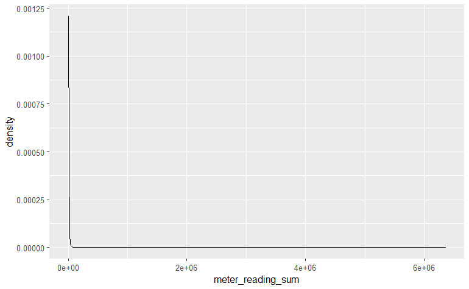

```r
ggplot2::ggplot(data=ff_train_agg, aes(x=meter_reading_sum)) +
  geom_density()
```

Resulting distribution is of the ‘power law’ type. It’s heavily biased to the left. It could be to some extent normalized by using ‘Log’ transformation. ‘+1’ is to avoid minus infinity when the log gets ‘0’ - prevents generation of NAs).

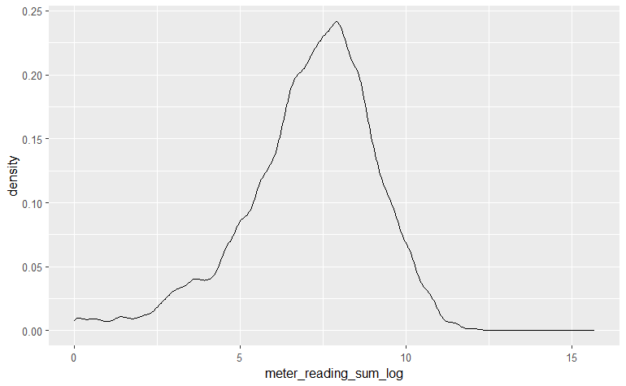

```r
# A new column
ff_train_agg$meter_reading_sum_log <- log(ff_train_agg$meter_reading_sum + 1)
ggplot(data=ff_train_agg, aes(x=meter_reading_sum_log)) +
  geom_density()
```

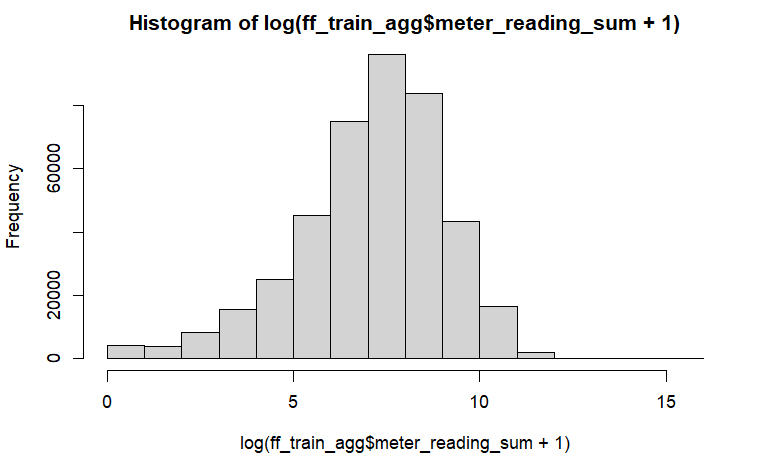

```r
hist(log(ff_train_agg$meter_reading_sum + 1))
```

#### Outcome variable Vs categories of all categorical variables

make sure that excel file ‘cat_var_after_data_cleansing’ is updated.

```r
pdf("C:/Users/Avishai/Documents/General/Personal/DS Course/Google drive content/Projects/Final project-ASHRAE-Great Energy Predictor III/Graphs-after completion of data cleansing/meter_reading_sum_log_uni_graphs.pdf")
options(repr.plot.width = 8, repr.plot.height = 8)                        # graph size
par(mfrow=c(2, 2))                                                        # number of rows and columns at the graph

# a csv file stores all the categorical variables - nominal and ordinal
cat_lst <- read.csv("C:/Users/Avishai/Documents/General/Personal/DS Course/Google drive content/Projects/Final project-ASHRAE-Great Energy Predictor III/csv files/cat_var_after_data_cleansing.csv")
prt_df <- ff_train_agg[is.na(ff_train_agg$meter_reading_sum_log) == F,]   # boxplot collapses when NUlls exist at the dependent variable
for (v in cat_lst$cat_variables) {
  boxplot(prt_df$meter_reading_sum_log ~ prt_df[[v]], main = v, cex.main = 0.85)
}

par(mfrow=c(1, 1))                                                        # show it all at once
dev.off()
```

Variable that were found to be affect the outcome variable are: ‘site_id’ ‘sw_primary_use_Parking_mode’ ‘sw_primary_use_ReligiousWorship_mode’ ‘sw_primary_use_Utility_mode’.

```r
# Deleting the outcome_log column generated earlier
ff_train_agg$meter_reading_sum_log <- NULL
```

#### Visual determination - **boxplots**

‘boxplot’ - describes the behavior of numeric variable’s distribution

```r
# Cyclical variables (contain "_x_" or "_y_" or "_x" or "_y")
cyclical_vars <- names(ff_train_agg)[grep("_x_|_y_|(_x$|_y$)", names(ff_train_agg))]

# variables that their value distributions have no meaning
exclude <- c(nominal, "date", cyclical_vars)

vars_for_boxplot <- setdiff(names(ff_train_agg), exclude)
```

‘boxplot’ function:

```r
pdf("C:/Users/Avishai/Documents/General/Personal/DS Course/Google drive content/Projects/Final project-ASHRAE-Great Energy Predictor III/Graphs-after completion of data cleansing/boxplot_uni_graphs.pdf")
options(repr.plot.width = 8, repr.plot.height = 8)      # graph size
par(mfrow=c(2, 3))                                      # number of rows and columns at the graph

for(v in vars_for_boxplot) {
    boxplot(ff_train_agg[[v]], main = v, cex.main = 0.80)
}
par(mfrow=c(1, 1))                                      # show it all at once
dev.off()
```

#### Visual determination - **scatter plots**

‘scatter plot’ - shows outliers of attributes. Horizontal axis is an index.

```r
# For runtime considerations, a random sample of the data is taken:
set.seed(4)
sample_df <- ff_train_agg %>% slice_sample(n = 10000)

pdf("C:/Users/Avishai/Documents/General/Personal/DS Course/Google drive content/Projects/Final project-ASHRAE-Great Energy Predictor III/Graphs-after completion of data cleansing/scatter_uni_graphs.pdf")
options(repr.plot.width = 8, repr.plot.height = 8)
par(mfrow=c(2, 3))

# 'date' - too many values that have no meaning at the graph
for(v in names(ff_train_agg)[!names(ff_train_agg) %in% "date"]) {
    # '+1' - as 'scatter.smooth' function can't receive zero at y axis, because of log scaling it uses
    # 'building_id' represented in the horizontal axis as an index
    scatter.smooth(as.numeric(sample_df[[v]]) + 1 ~ sample_df$building_id , main = v, ylab = v,
        family = "symmetric", lpars = list(col = "red", lwd = 2, lty = 2))
}

par(mfrow=c(1, 1))
dev.off()
```

#### Missing Value exploration

Stats that help understanding the amount of missing values:

```r
# Find columns with NAs
missingCols <- getMissingness(ff_train_agg, getRows = T)
```

```
[[1]]
[1] var      na.count rate
<0 rows> (or 0-length row.names)

[[2]]
[1] "This dataset has 418851 (100%) complete rows. Original data has 418851 rows."
```

```r
missingCols$missingness
```

| var | na.count | rate |
| --- | --- | --- |

```r
missingCols$message
```

```
[1] "This dataset has 418851 (100%) complete rows. Original data has 418851 rows."
```

Visualization of missing values

A heatmap of the missing data - only on columns that have missing values:

‘vis_miss’ function:

```r
pdf("C:/Users/Avishai/Documents/General/Personal/DS Course/Google drive content/Projects/Final project-ASHRAE-Great Energy Predictor III/Graphs-after completion of data cleansing/Heatmap Missing Percentage Graph.pdf")
options(repr.plot.width = 25, repr.plot.height = 25)

# subset the data frame to include only the columns that have missing values
vis_miss(ff_train_agg[, missingCols$missingness$var], warn_large_data = FALSE) +
  theme(plot.title = element_text(size = 10),
        axis.text.x = element_text(size = 5, angle = 90),
        axis.title.y = element_blank())
```

```
Error in if (p_miss == 0) { : missing value where TRUE/FALSE needed
```

Another visualization:

Converting ‘date’ variable’s data type from ‘date’ to ‘int’ as it can’t receive 0, 1 when it’s a date data type, in the next chunk:

```r
ff_train_agg$date <- as.integer(ff_train_agg$date)
```

Following the factorizing operated earlier on ‘building_id’ column, it now can’t receive 0 or 1 for indicating its NA existence, as it doesn’t have 0 or 1 as categories. Therefore I will add to the column 0 and 1 as levels, just for that reason.

```r
pdf("C:/Users/Avishai/Documents/General/Personal/DS Course/Google drive content/Projects/Final project-ASHRAE-Great Energy Predictor III/Graphs-after completion of data cleansing/Missingness plot.pdf")

ff_train_agg_na <- ff_train_agg
levels(ff_train_agg_na$building_id) <- c(levels(ff_train_agg_na$building_id), 0, 1)
ff_train_agg_na[!is.na(ff_train_agg_na)] <- 0
ff_train_agg_na[is.na(ff_train_agg_na)] <- 1
gg_miss_var <- naniar::gg_miss_var(ff_train_agg_na)
gg_miss_var

dev.off()
```

```r
unique_lengths <- sapply(ff_train_agg, function(col) length(unique(col)))
unique_lengths
```